# Exercise Manner Prediction

M. Klein

11-1-2017

# Introduction

One thing that people regularly do is quantify how much of a particular activity they do, but they rarely quantify how well they do it. In this project, using data from accelerometers on the belt, forearm, arm, and dumbell of 6 participants, a model is created to predict the quality of the exercise.

# Background

Using devices such as Jawbone Up, Nike FuelBand, and Fitbit it is now possible to collect a large amount of data about personal activity relatively inexpensively. These type of devices are part of the quantified self movement – a group of enthusiasts who take measurements about themselves regularly to improve their health, to find patterns in their behavior, or because they are tech geeks. One thing that people regularly do is quantify how much of a particular activity they do, but they rarely quantify how well they do it. In this project, your goal will be to use data from accelerometers on the belt, forearm, arm, and dumbell of 6 participants. They were asked to perform barbell lifts correctly and incorrectly in 5 different ways. More information is available from the website here: http://groupware.les.inf.puc-rio.br/har (see the section on the Weight Lifting Exercise Dataset).

# Data

## Loading the data

The data consists of a training set and a test set. The test set has no classifier, the final modal will be use to predict the quality of the exercise for the test set.

```r
if (!file.exists("pml-training.csv"))
    download.file("https://d396qusza40orc.cloudfront.net/predmachlearn/pml-training.csv",
                  "pml-training.csv", method="curl")
if (!file.exists("pml-testing.csv"))
    download.file("https://d396qusza40orc.cloudfront.net/predmachlearn/pml-testing.csv",
                  "pml-testing.csv", method="curl")

training <- read.csv("pml-training.csv")
testing <- read.csv("pml-testing.csv")
```

## Cleaning data

```r
tr2 <- training[, colSums(sapply(training, is.na))/nrow(training) < .97]
tr2 <- tr2[, colSums(sapply(tr2, function(x) x ==""))/nrow(training) < .97]
tr2 <- tr2 %>% select(-c(X, cvtd_timestamp, raw_timestamp_part_1, raw_timestamp_part_2, new_window, num_window))
nms <- names(tr2)
tt2 <- testing[,nms[-which(nms=="classe")]]

str(tr2)
```

```
## 'data.frame':    19622 obs. of  54 variables:
##  $ user_name           : Factor w/ 6 levels "adelmo","carlitos",..: 2 2 2 2 2 2 2 2 2 2 ...
##  $ roll_belt           : num  1.41 1.41 1.42 1.48 1.48 1.45 1.42 1.42 1.43 1.45 ...
##  $ pitch_belt          : num  8.07 8.07 8.07 8.05 8.07 8.06 8.09 8.13 8.16 8.17 ...
##  $ yaw_belt            : num  -94.4 -94.4 -94.4 -94.4 -94.4 -94.4 -94.4 -94.4 -94.4 -94.4 ...
##  $ total_accel_belt    : int  3 3 3 3 3 3 3 3 3 3 ...
##  $ gyros_belt_x        : num  0 0.02 0 0.02 0.02 0.02 0.02 0.02 0.02 0.03 ...
##  $ gyros_belt_y        : num  0 0 0 0 0.02 0 0 0 0 0 ...
##  $ gyros_belt_z        : num  -0.02 -0.02 -0.02 -0.03 -0.02 -0.02 -0.02 -0.02 -0.02 0 ...
##  $ accel_belt_x        : int  -21 -22 -20 -22 -21 -21 -22 -22 -20 -21 ...
##  $ accel_belt_y        : int  4 4 5 3 2 4 3 4 2 4 ...
##  $ accel_belt_z        : int  22 22 23 21 24 21 21 21 24 22 ...
##  $ magnet_belt_x       : int  -3 -7 -2 -6 -6 0 -4 -2 1 -3 ...
##  $ magnet_belt_y       : int  599 608 600 604 600 603 599 603 602 609 ...
##  $ magnet_belt_z       : int  -313 -311 -305 -310 -302 -312 -311 -313 -312 -308 ...
```

[output cut: 40 more lines]

# Feature selection

Random Forest will be used to build the model. To determine the number of predictors to use ‘Random Forest Cross-Valdidation for feature selection’ (rfcv) is used on the training set.

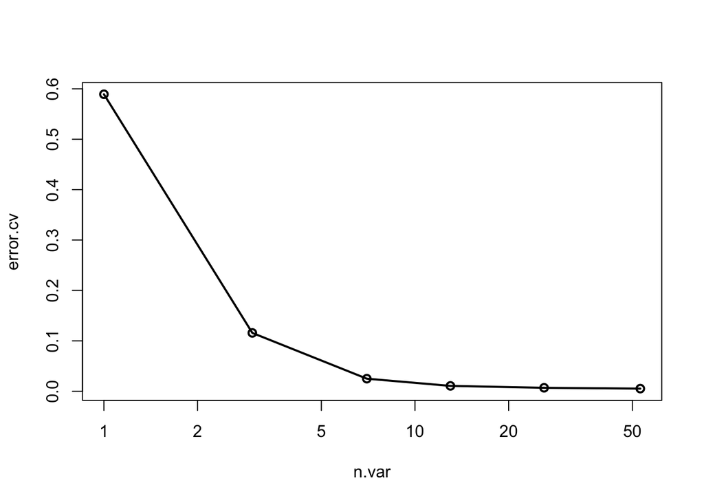

```r
set.seed(2017-01-11)
rf.cv<-rfcv(tr2[,-54],tr2$class, cv.fold=10, nodesize=10, ntree=200)
with(rf.cv, plot(n.var, error.cv, log="x", type="o", lwd=2))
```

```r
print(rf.cv$error.cv)
```

```
##          53          26          13           7           3           1
## 0.005249210 0.006880033 0.010651310 0.024971970 0.115737438 0.589185608
```

To be able to predict the 20 cases in the testset correctly with a high probability the model should be very accurate. Each observation in the test data set is independent of the others. If a represents the accuracy of a machine learning model, then the probability of correctly predicting 20 out of 20 test cases with the model in question is a^20, because the probability of the total is equal to the product of the independent probabilities.

To have at least 80% chanche to predict all 20 cases correctly, the model must have an accurancy of at least 99% (0.99 ^ 20 = 81.79%).

The result of rfcv() shows that 26 predictors give an error rate of 0.69% and a accurance of 99.31%. Using more predictors only in a small decrease in the error rate but can result in overfitting.

For the final model 26 predictors will be used.

## Selection predictors

```r
mdAll <- randomForest(tr2[,-54],tr2$classe, nodesize=10, ntree=200)
import <- importance(mdAll)
import <- import[order(import, decreasing=TRUE),,drop=FALSE]
import <- import[1:numPred,,drop=FALSE]
import
```

```
##                      MeanDecreaseGini
## roll_belt                   1272.6933
## yaw_belt                     880.7252
## pitch_forearm                759.6947
## magnet_dumbbell_z            731.5764
## pitch_belt                   698.6673
## magnet_dumbbell_y            624.7211
## roll_forearm                 565.9771
## magnet_dumbbell_x            505.9486
## roll_dumbbell                410.1501
## accel_dumbbell_y             409.8711
## accel_belt_z                 398.6620
## magnet_belt_z                367.8509
## magnet_belt_y                356.5655
## accel_dumbbell_z             327.1912
## roll_arm                     310.9739
## accel_forearm_x              307.9007
## gyros_belt_z                 292.2341
## total_accel_dumbbell         279.6787
## yaw_arm                      262.8873
## magnet_forearm_z             262.4204
## yaw_dumbbell                 243.8358
## magnet_arm_x                 243.3682
## accel_forearm_z              235.9607
## gyros_dumbbell_y             225.3378
## magnet_belt_x                223.6159
## accel_dumbbell_x             220.1150
```

# Final Model

The final modal is created on the whole data set with cross validation.

```r
cluster <- makeCluster(detectCores() - 1) # convention to leave 1 core for OS
registerDoParallel(cluster)

fitControl <- trainControl(method = "cv",
                           number = 10,
                           allowParallel = TRUE)

intrain <- createDataPartition(y=tr2$classe, p=0.7, list=FALSE)
predictors <- tr2[intrain,rownames(import)]
predictorsClasse <- tr2[intrain,54]
validation <- tr2[-intrain,rownames(import)]
validationClasse <- tr2[-intrain,54]
predictorsA <-  tr2[,rownames(import)]

md <- train(predictorsA,tr2$classe, method="rf", trControl = fitControl, nodesize = 10, ntree = 200)

print(md)
```

```
## Random Forest
##
## 19622 samples
##    26 predictor
##     5 classes: 'A', 'B', 'C', 'D', 'E'
##
## No pre-processing
## Resampling: Cross-Validated (10 fold)
## Summary of sample sizes: 17659, 17660, 17661, 17659, 17660, 17660, ...
## Resampling results across tuning parameters:
##
##   mtry  Accuracy   Kappa
##    2    0.9902660  0.9876863
##   14    0.9928145  0.9909109
##   26    0.9848132  0.9807904
##
## Accuracy was used to select the optimal model using  the largest value.
## The final value used for the model was mtry = 14.
```

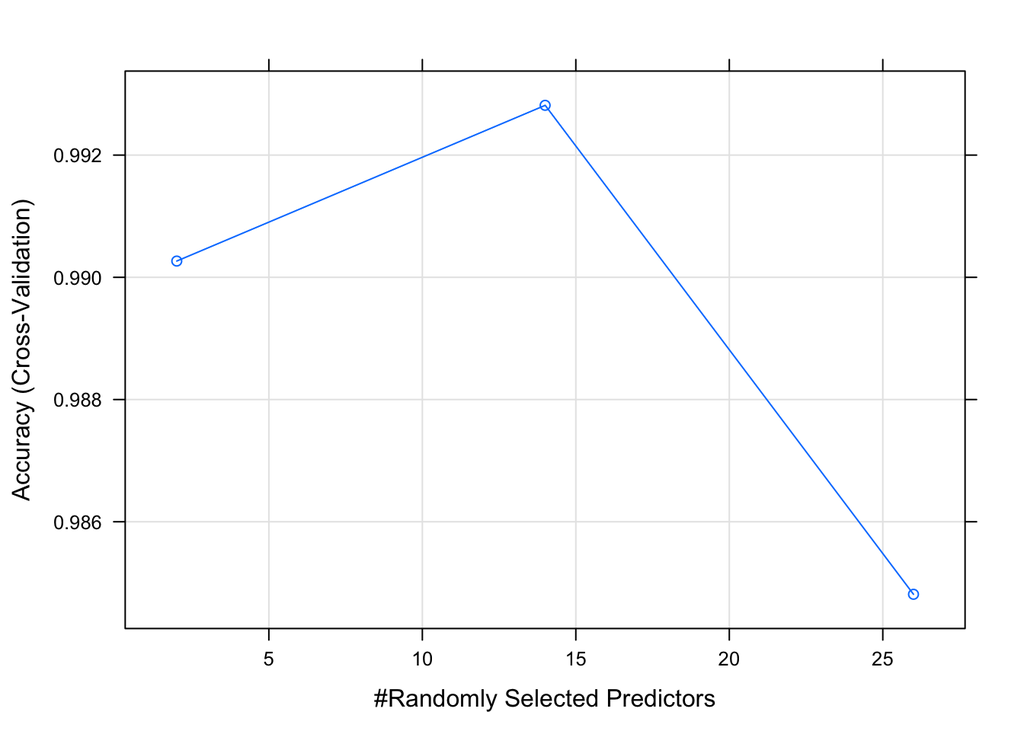

```r
plot(md)
```

The final modal uses mtry = 14 with an accurancy of 99.28%. This is better than the minimal threshold of 99%. The in of sample error is 0.72%

## Prediction testset

```r
test <- tt2[,rownames(import)]
testPred <- predict(md, test)
testPred
```

```
##  [1] B A B A A E D B A A B C B A E E A B B B
## Levels: A B C D E
```

The prediction of the model resulted in 100% score in the quiz. Out of sample error is 0%